# bearing_fault_analysis

2024-08-24

# Step 1: Data Collection

Download Data: Normal Baseline Data: Download 12k Drive End Bearing Fault Data: Download 48k Drive End Bearing Fault Data: Download 12k Fan-End Bearing Fault Data: Download

# Step 2: Data Preparation

Read and Organize Data: Use the R.matlab library in R to read the Matlab files. Read CSV files to for analysis Organize the data into a structured format (e.g., data frames or lists) for analysis.

# Step 3: Preliminary Analysis

Compute HxC Points: Use the statOrdPattHxC library to compute the HxC point for each compatible time series. Check the documentation to match time series with the same measurement.

# Step 4: Visualization

Visualize Data: Plot the HxC points in the HxC manifold. Identify if different categories form distinct clusters.

# Step 5: Literature Review

Analyze Literature: Analyze the references from the Web of Science and additional references from Scopus. Identify relevant scientific questions and gaps in the literature. Review existing studies on Ordinal Patterns or Permutation Entropy.

## Research on the Use of CWRU Bearing Data Center Data

The Case Western Reserve University (CWRU) Bearing Data Center provides a well-known dataset extensively used in research for bearing fault diagnosis and machine learning applications. https://engineering.case.edu/bearingdatacenter/welcome

```r
# Define the base path of the project using rprojroot
base_path <- find_root(has_file("README.md"))

# Build the relative path to the Excel file
file_path <- file.path(base_path, "Data", "csv", "Normal_baseline_data.csv")
plot_path <- file.path(base_path, "Plots")

if(!dir.exists(plot_path)) {
  dir.create(plot_path)
}

#Initialize lists to store time series data and results
DE_Time <- list()
FE_Time <- list()
BA_Time <- list()
results <- list()

read_data_file <- function(file_path){
  # Check if the file exists
  if (!file.exists(file_path)) {
    stop("The file does not exist: ", file_path)
  }

  # Read the CSV file
  data_normal <- read_csv(file_path, show_col_types = FALSE)

  # Select specific columns for analysis
  selected_columns <- data_normal %>%
    select(Fault_diameter, Motor_load, RPM, DE_time, FE_time, BA_time)

  # Example: Print the first few rows of the selected columns
  #print(head(selected_columns))
  return (selected_columns)

}
```

## Read data and prepare relevant time series

```
## # A tibble: 6 × 6
##   Fault_diameter Motor_load   RPM  DE_time FE_time BA_time
##   <lgl>               <dbl> <dbl>    <dbl>   <dbl> <lgl>
## 1 NA                      0  1796  0.0532   0.146  NA
## 2 NA                      0  1796  0.0887   0.0978 NA
## 3 NA                      0  1796  0.0997   0.0549 NA
## 4 NA                      0  1796  0.0586   0.0370 NA
## 5 NA                      0  1796 -0.00459  0.0544 NA
## 6 NA                      0  1796 -0.0570   0.0212 NA
```

# Computing variances

We will compute the asymptotic variances from each time series.

Asymptotic variances

|  | Shannon |
| --- | --- |
| DE time | 1.370e-01 |
| FE time | 1.244e-01 |

Compute and display two/three entropies with their confidence intervals in the $H\times C$ plane.

```r
data("LinfLsup")

x1sub <- de_time_data
x2sub <- fe_time_data
x3sub <- ba_time_data

if(sum(!is.na(x3sub)) > 0) {
  ShannonEntropies <- c(
  HShannon(OPprob(x1sub, emb=D)),
  HShannon(OPprob(x2sub, emb=D)),
  HShannon(OPprob(x3sub, emb=D))
)
}else{
  ShannonEntropies <- c(
  HShannon(OPprob(x1sub, emb=D)),
  HShannon(OPprob(x2sub, emb=D)))
}


if(sum(!is.na(x3sub)) > 0) {
  StatisticalComplexities <- c(
    StatComplexity(OPprob(x1sub, emb=D)),
    StatComplexity(OPprob(x2sub, emb=D)),
    StatComplexity(OPprob(x3sub, emb=D))
  )
}else{
  StatisticalComplexities <- c(
    StatComplexity(OPprob(x1sub, emb=D)),
    StatComplexity(OPprob(x2sub, emb=D))
  )
}
ShannonEntropies
```

```
## [1] 0.6826654 0.7239222
```

```r
StatisticalComplexities
```

```
## [1] 0.2637758 0.2405618
```

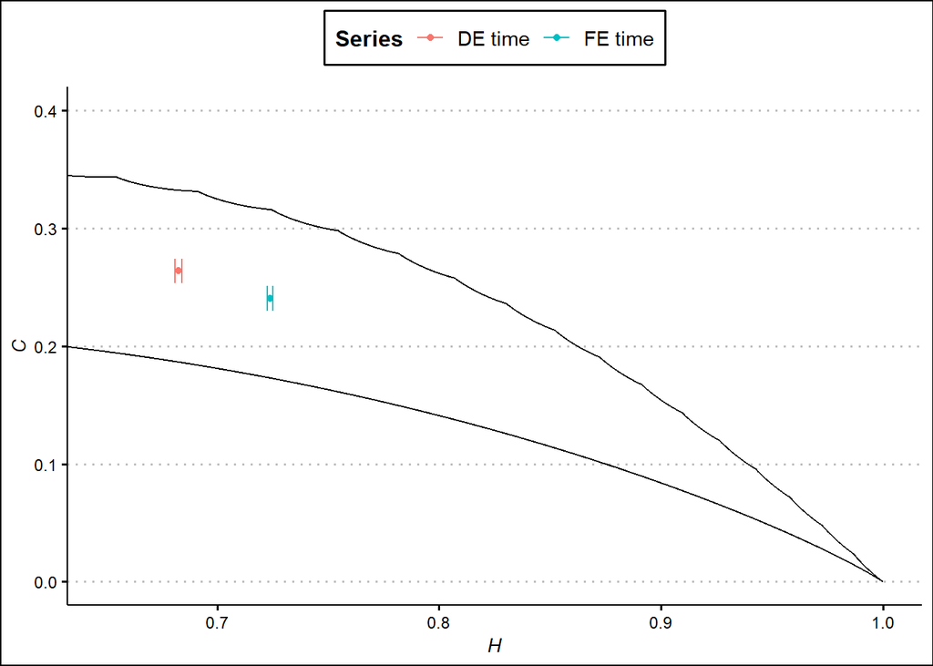

```r
alpha <- 0.05
StandardDeviations <- sqrt(Variances[,1])
SemiLength <- StandardDeviations/sqrt(length(x1sub)-D)*qnorm(1-alpha/2)
  # The three time series have the same length, but they could be different

features_c <- c("DE time", "FE time")

if(sum(!is.na(ba_time_data)) > 0) {
  features_c <- c("DE time", "FE time", "BA_time")
}

HCPoints <- data.frame(H=ShannonEntropies,
                       C=StatisticalComplexities,
                       STD=StandardDeviations,
                       SemiLength=SemiLength,
                       Series=as.factor(features_c))

directory_path_complexity_plane = file.path(plot_path, "fault_analysis")

if(!dir.exists(directory_path_complexity_plane)) {
        dir.create(directory_path_complexity_plane)
}

pdf_file_name <- file.path(directory_path_complexity_plane, paste(sprintf("confidence_interval_Embed_dim_%s_Motor_load_%s", D, ML), ".pdf"))

ggplot(subset(LinfLsup, Side=="Lower" & Dimension==as.character(D)),
       aes(x=H, y=C)) +
  geom_line() +
  geom_line(data=subset(LinfLsup, Side=="Upper" & Dimension==as.character(D)),
            aes(x=H, y=C)) +
  xlab(expression(italic(H))) +
  ylab(expression(italic(C))) +
  geom_point(data=HCPoints, aes(x=H, y=C, col=Series)) +
  geom_errorbarh(data=HCPoints, aes(xmin=H-SemiLength, xmax=H+SemiLength, group=Series, col=Series)) +
  coord_cartesian(xlim=c(0.65, 1), ylim=c(0, 0.4))
```

```r
ggsave(pdf_file_name, width=16, height = 10, units = "in", dpi = 300)
```